# Analysis and prediction of car accidents in Los Alngeles based on the collisions data from 2010 to 2019

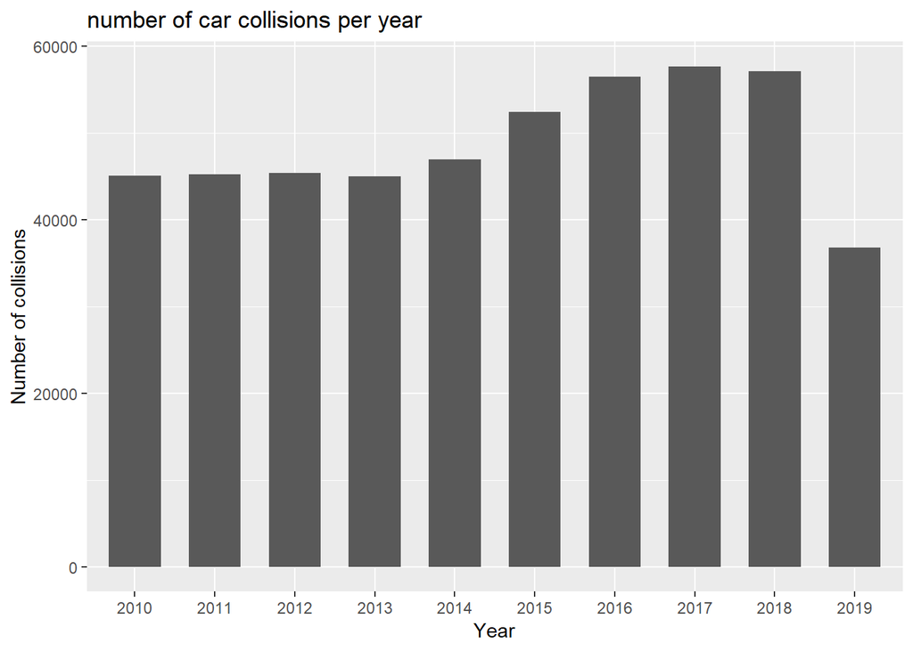

```r
ggplot(data=year_wise_count,aes(x=as.factor(year),y=n))+
  labs(x='Year',y='Number of collisions',title = 'number of car collisions per year')+
  geom_bar(width = 0.65, stat = "identity")
```

```r
month_wise_count<-collision %>% group_by(month) %>% count()
month_wise_count
```

| month | n |
| --- | --- |
| Jan | 39994 |
| Feb | 39189 |
| Mar | 43872 |
| Apr | 41341 |
| May | 42028 |
| Jun | 41334 |
| Jul | 42312 |
| Aug | 43893 |
| Sep | 37714 |
| Oct | 40701 |

[output cut: 2 more lines]

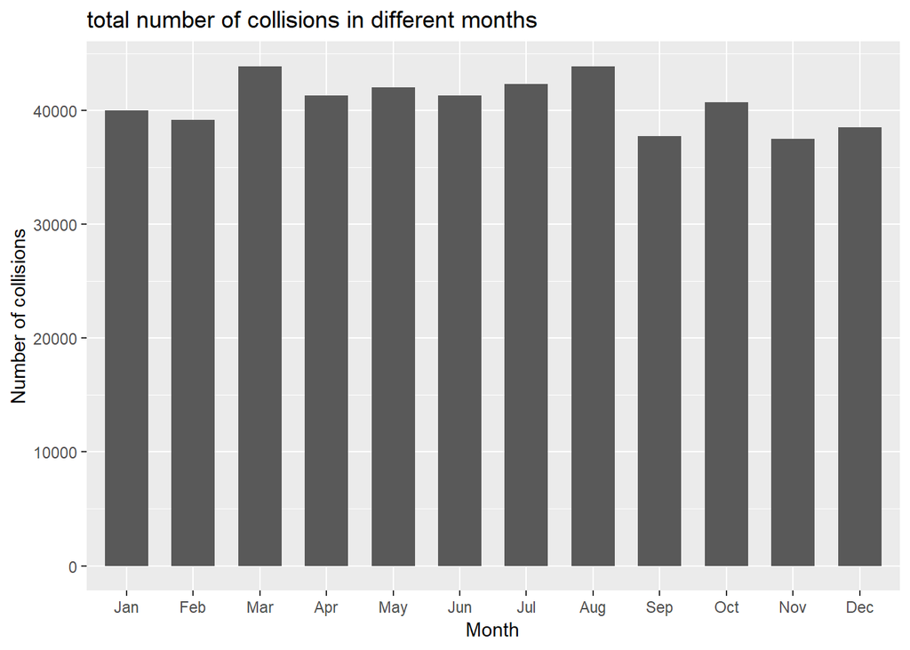

```r
ggplot(data=month_wise_count,aes(x=as.factor(month),y=n))+
  labs(x='Month',y='Number of collisions',title = 'total number of collisions in different months')+
  geom_bar(width = 0.65,stat = "identity")
```

```r
day_wise_count<-collision %>% group_by(weekday) %>% count()
day_wise_count
```

| weekday | n |
| --- | --- |
| Sun | 63787 |
| Mon | 67549 |
| Tue | 68829 |
| Wed | 69412 |
| Thu | 70644 |
| Fri | 77630 |
| Sat | 70533 |

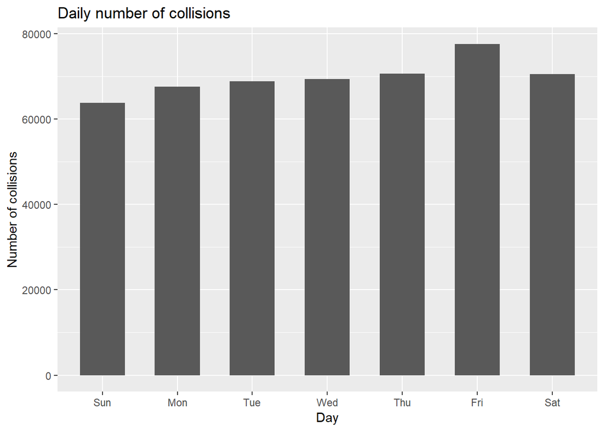

```r
ggplot(data=day_wise_count,aes(x=as.factor(weekday),y=n))+
  labs(x='Day',y='Number of collisions',title = 'Daily number of collisions')+
  geom_bar(width=0.6,stat = "identity")
```

## Time series analysis

According to the results reported in the previous sections, area “77th Street” has the highest number of collisions among all areas in Los Angeles. Therefore, this area is the most critical area in the city. So we start out study with this area, do some statistical analysis, compare the results of different models in predicting the future collisions, then we extend the study to other areas in LA.

```r
collision_daily <- collision[collision$area_name=='77th Street',] %>%
  group_by(date) %>%
  summarize(count = n()) %>%
  arrange(date)
```

The graph below shows the number of daily collisions in “77th street” from 2010 to 2019.

```r
collision_daily
```

| date | count |
| --- | --- |
| 2010-01-01 | 11 |
| 2010-01-02 | 4 |
| 2010-01-03 | 6 |
| 2010-01-04 | 7 |
| 2010-01-05 | 6 |
| 2010-01-06 | 6 |
| 2010-01-07 | 5 |
| 2010-01-08 | 3 |
| 2010-01-09 | 4 |
| 2010-01-10 | 3 |

[output cut: 3515 more lines]

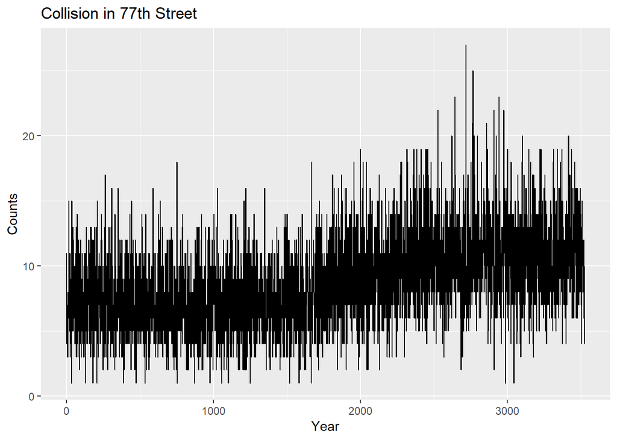

```r
collision_ts<-as.ts(collision_daily$count)

autoplot(collision_ts) +
  ggtitle("Collision in 77th Street") +
  xlab("Year") + ylab("Counts")
```

ACF and PACF graphs give us some ideas about the seasonality of the time series and some hints to improve the model. According to ACF graph, the time series is not stationary. We do the first order differencing to see if any improvement happens. Results show that after aplying first order differencing, the time series gets more strationary. Also taking log doesnt improve the time series significantly. The variation of the “counts” is almsost contant in the different time periods.

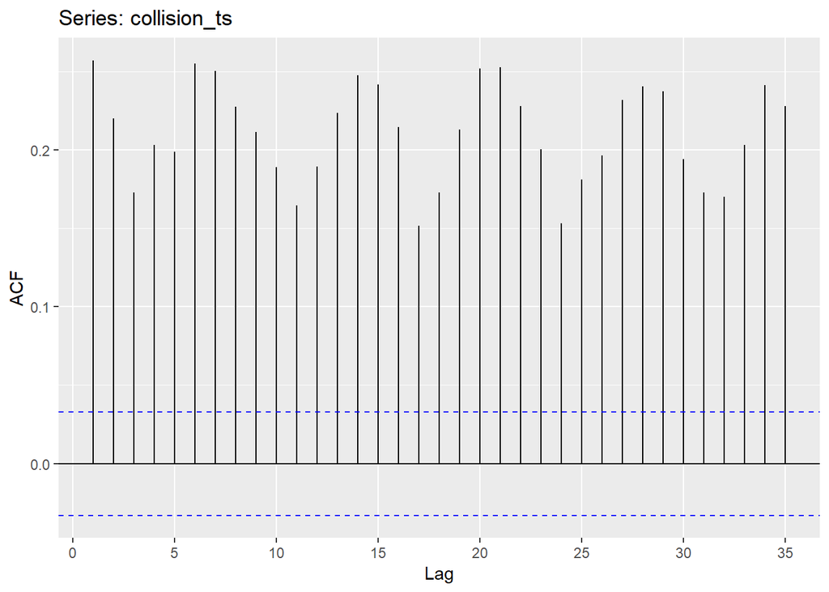

```r
ggAcf(collision_ts)
```

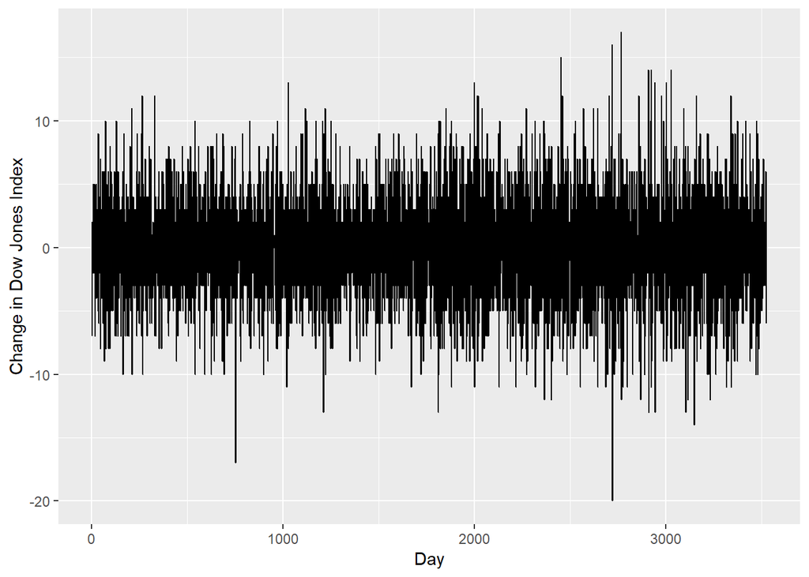

```r
autoplot(diff(collision_ts)) + ylab("Change in Dow Jones Index") + xlab("Day")
```

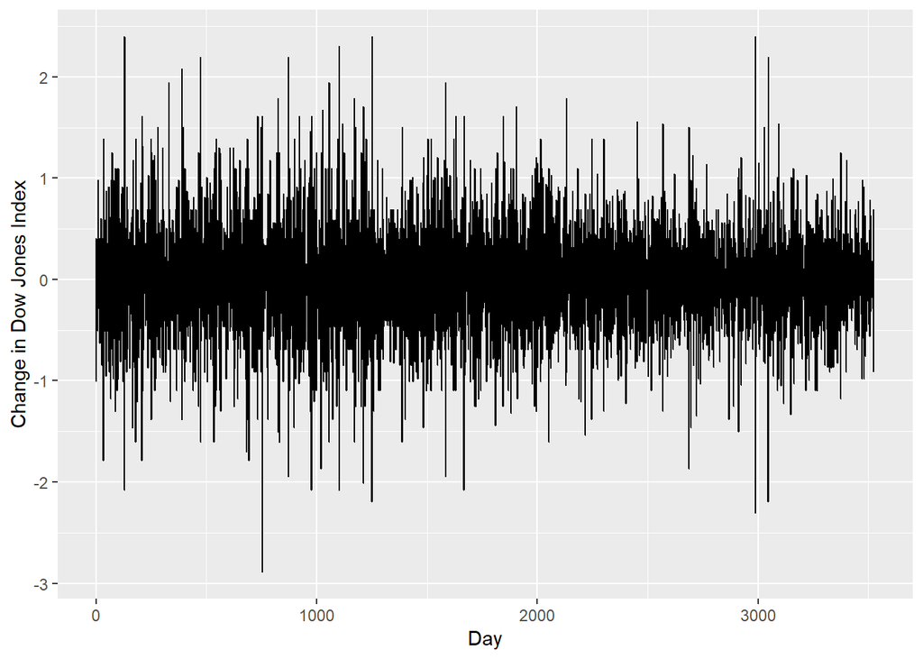

```r
autoplot(diff(log(collision_ts))) + ylab("Change in Dow Jones Index") + xlab("Day")
```

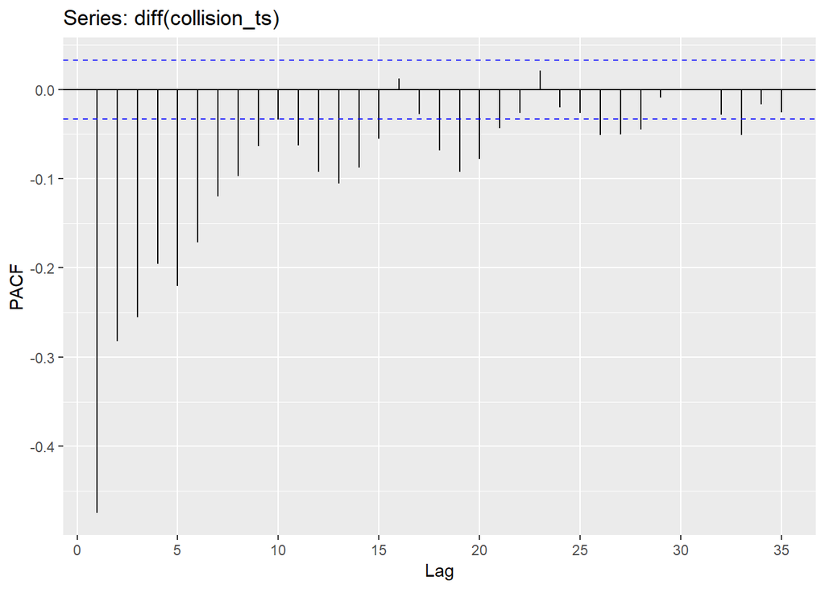

```r
ggPacf(diff(collision_ts))
```

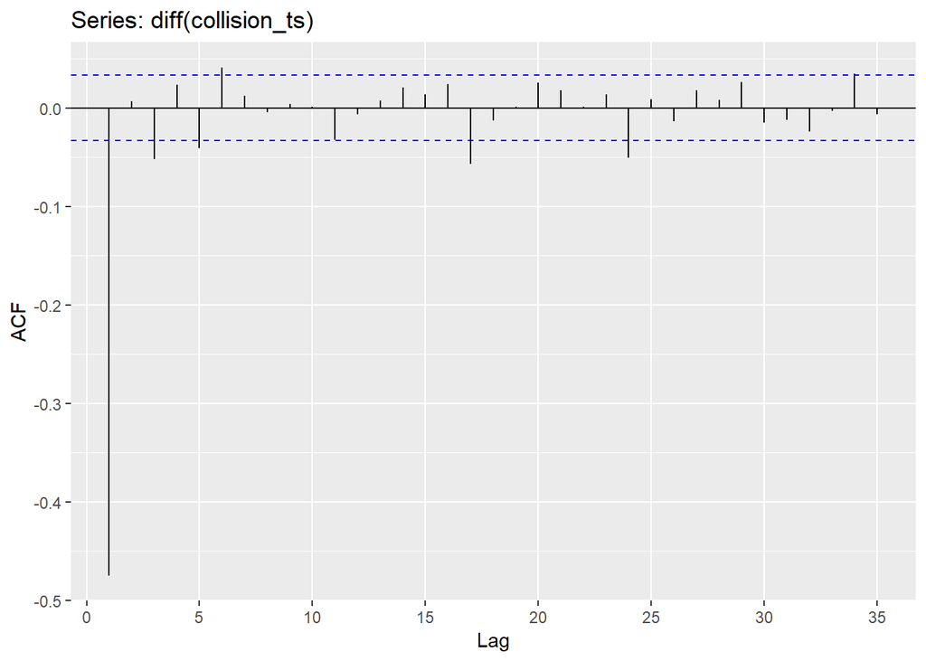

```r
ggAcf(diff(collision_ts))
```

Also kpss test of the time series shown below confirms that the original time series is not stationary

(t-stat is larger than the critical values: Value of test-statistic is: 23.2493 Critical value for a significance level of: 10pct 5pct 2.5pct 1pct critical values 0.347 0.463 0.574 0.739).

(Also “ndiffs” suggests that first order differencing is enough for this time series) After taking the difference, kpss test confirms that the time series is stationary

(Value of test-statistic is: 0.0033 Critical value for a significance level of: 10pct 5pct 2.5pct 1pct critical values 0.347 0.463 0.574 0.739).

```r
summary(ur.kpss(collision_ts))
```

```
##
## #######################
## # KPSS Unit Root Test #
## #######################
##
## Test is of type: mu with 9 lags.
##
## Value of test-statistic is: 23.2493
##
## Critical value for a significance level of:
##                 10pct  5pct 2.5pct  1pct
## critical values 0.347 0.463  0.574 0.739
```

```r
ndiffs(collision_ts)
```

```
## [1] 1
```

```r
collision_ts %>% diff() %>% ur.kpss() %>% summary()
```

```
##
## #######################
## # KPSS Unit Root Test #
## #######################
##
## Test is of type: mu with 9 lags.
##
## Value of test-statistic is: 0.0033
##
## Critical value for a significance level of:
##                 10pct  5pct 2.5pct  1pct
## critical values 0.347 0.463  0.574 0.739
```

First we try with auto ARIMA. It suggests ARIMA(3,1,1). The AIC and BIC scores are shown below:

```r
auto.arima(collision_ts)
```

```
## Series: collision_ts
## ARIMA(3,1,1) with drift
##
## Coefficients:
##          ar1     ar2      ar3      ma1  drift
##       0.0546  0.0073  -0.0530  -0.9898  1e-03
## s.e.  0.0170  0.0170   0.0169   0.0022  6e-04
##
## sigma^2 estimated as 10.02:  log likelihood=-9061
## AIC=18133.99   AICc=18134.01   BIC=18171
```

Then I tried to combine different numbers of p and q (from 0 to 6) and stored all AIC and BIC scores.The model which provides the minimum AIC or BIC (preferred) will be selected:

```r
outp <- matrix(0,7^2,5)
count <- 1
for(i in 0:6){
  for(j in 0:6){
    model <- Arima(collision_ts,c(i,1,j))
    outp[count,] <- c(i,1,j,AIC(model),BIC(model))
    count <- count + 1
  }
}
outp <- data.table(outp)
names(outp) <- c('p','d','q','aic','bic')
outp
```

| p | d | q | aic | bic |
| --- | --- | --- | --- | --- |
| 0 | 1 | 0 | 20347.74 | 20353.91 |
| 0 | 1 | 1 | 18149.18 | 18161.52 |
| 0 | 1 | 2 | 18140.90 | 18159.40 |
| 0 | 1 | 3 | 18142.24 | 18166.91 |
| 0 | 1 | 4 | 18136.06 | 18166.90 |
| 0 | 1 | 5 | 18137.81 | 18174.82 |
| 0 | 1 | 6 | 18137.58 | 18180.76 |
| 1 | 1 | 0 | 19449.71 | 19462.04 |
| 1 | 1 | 1 | 18140.71 | 18159.21 |
| 1 | 1 | 2 | 18142.68 | 18167.35 |

[output cut: 39 more lines]

```r
outp[aic==0,]$aic <- 9999
outp[bic==0,]$bic <- 9999
outp[which.min(outp$aic),,]
```

| p | d | q | aic | bic |
| --- | --- | --- | --- | --- |
| 4 | 1 | 5 | 18007.76 | 18069.43 |

```r
outp[which.min(outp$bic),,]
```

| p | d | q | aic | bic |
| --- | --- | --- | --- | --- |
| 3 | 1 | 4 | 18011.38 | 18060.71 |

ARIMA(3,1,4) provides the minimum BIC: 18060.71 ARIMA(4,1,5) provides the minimum AIC: 18007.76

from auto arima we had : ARIMA(3,1,1) with BIC of 18171 Since lower BIC and AIC are better, the auto arima result shouldnt be selected. In the tables below, we see all the models,ordered based on BICs and AICs:

```r
outp[order(bic),]
```

| p | d | q | aic | bic |
| --- | --- | --- | --- | --- |
| 3 | 1 | 4 | 18011.38 | 18060.71 |
| 3 | 1 | 5 | 18010.65 | 18066.16 |
| 4 | 1 | 4 | 18011.70 | 18067.21 |
| 4 | 1 | 5 | 18007.76 | 18069.43 |
| 6 | 1 | 4 | 18008.99 | 18076.83 |
| 4 | 1 | 6 | 18009.80 | 18077.64 |
| 5 | 1 | 5 | 18009.89 | 18077.73 |
| 5 | 1 | 6 | 18011.80 | 18085.80 |
| 6 | 1 | 5 | 18011.81 | 18085.82 |
| 6 | 1 | 6 | 18012.38 | 18092.56 |

[output cut: 39 more lines]

```r
outp[order(aic),]
```

| p | d | q | aic | bic |
| --- | --- | --- | --- | --- |
| 4 | 1 | 5 | 18007.76 | 18069.43 |
| 6 | 1 | 4 | 18008.99 | 18076.83 |
| 4 | 1 | 6 | 18009.80 | 18077.64 |
| 5 | 1 | 5 | 18009.89 | 18077.73 |
| 3 | 1 | 5 | 18010.65 | 18066.16 |
| 3 | 1 | 4 | 18011.38 | 18060.71 |
| 4 | 1 | 4 | 18011.70 | 18067.21 |
| 5 | 1 | 6 | 18011.80 | 18085.80 |
| 6 | 1 | 5 | 18011.81 | 18085.82 |
| 6 | 1 | 6 | 18012.38 | 18092.56 |

[output cut: 39 more lines]

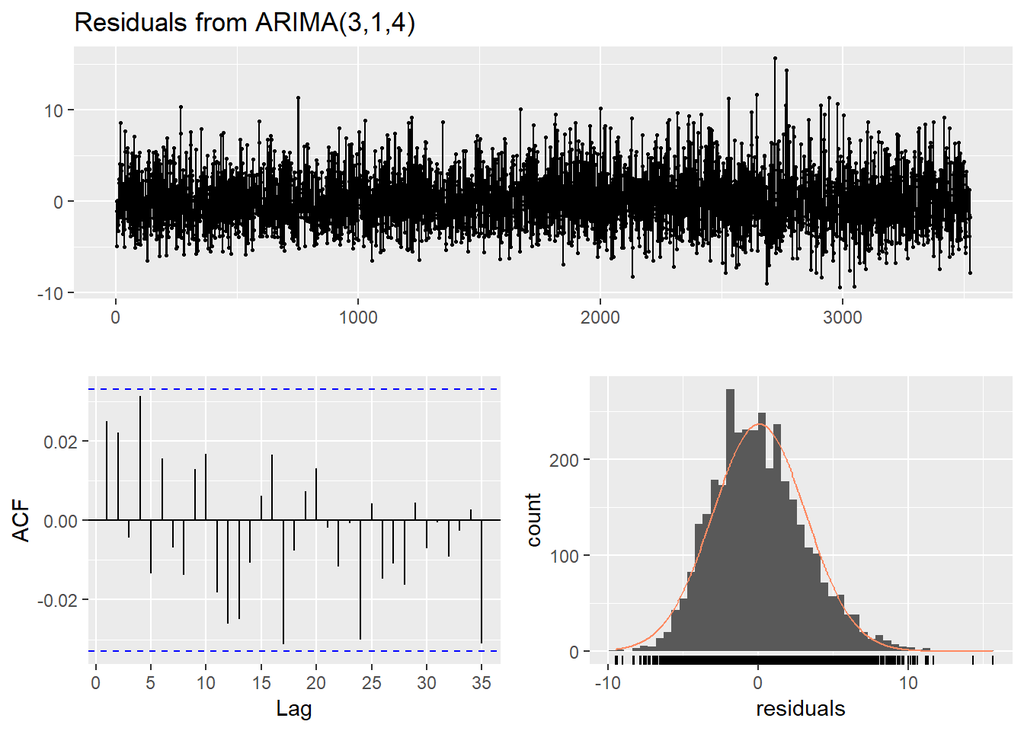

```
##
##  Ljung-Box test
##
## data:  Residuals from ARIMA(3,1,4)
## Q* = 11.354, df = 3, p-value = 0.009958
##
## Model df: 7.   Total lags used: 10
```

```r
fit <- arima(collision_ts, order = c(3,1,4))
checkresiduals(fit)
```

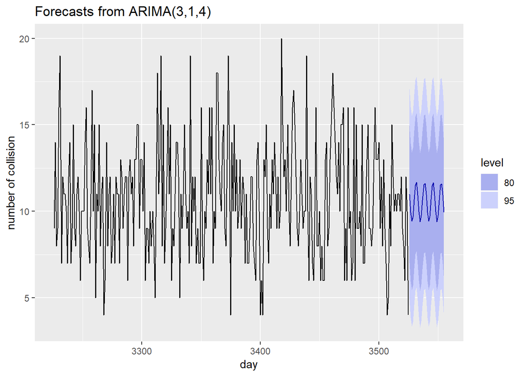

```r
fit%>%forecast(h=30)%>%autoplot(include=300)+xlab("day")+ylab("number of collision")
```

If we check the residuals of auto arima model, we see that the errors are not stationary so it is not a good model to predict the future events (its variation is a lot):

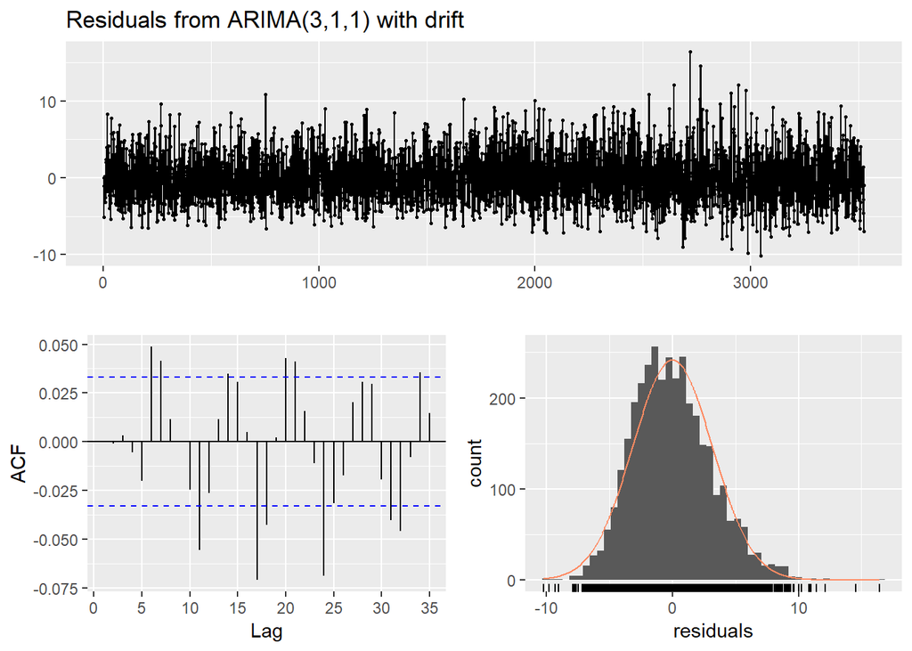

```
##
##  Ljung-Box test
##
## data:  Residuals from ARIMA(3,1,1) with drift
## Q* = 18.616, df = 5, p-value = 0.002265
##
## Model df: 5.   Total lags used: 10
```

```r
fit <- auto.arima(collision_ts)
checkresiduals(fit)
```

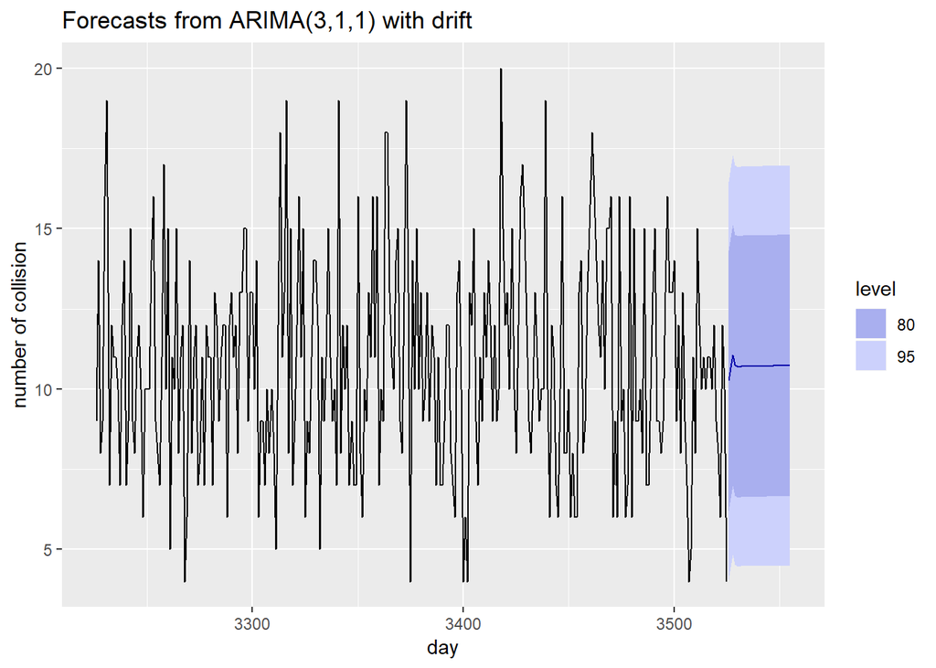

```r
fit%>%forecast(h=30)%>%autoplot(include=300)+xlab("day")+ylab("number of collision")
```

Here we make train and test sets to test the accuracy of the model. I chose the last 25 days of the time series as the test set:

```r
collision_train<-window(collision_ts,end=3500)
collision_test<-window(collision_ts,start=3501)
collision_test
```

```
## Time Series:
## Start = 3501
## End = 3525
## Frequency = 1
##  [1]  9 12  8 13  9  7  4  5 11  8 15 12 10 11 10 11 11 10 12  9  8  6 12
## [24] 10  4
```

```r
fit_1 <- arima(collision_train, order = c(3,1,4))
collision_tr<-forecast(fit_1,h=25)

collision_tr
```

```
##      Point Forecast    Lo 80    Hi 80    Lo 95    Hi 95
## 3501      10.111815 6.128782 14.09485 4.020291 16.20334
## 3502      11.081829 7.098400 15.06526 4.989700 17.17396
## 3503      11.943782 7.960258 15.92731 5.851507 18.03606
## 3504      12.081230 8.097705 16.06476 5.988955 18.17351
## 3505      11.359861 7.376276 15.34345 5.267494 17.45223
## 3506      10.355723 6.371832 14.33961 4.262887 16.44856
## 3507       9.794732 5.809811 13.77965 3.700322 15.88914
## 3508      10.128917 6.143098 14.11473 4.033134 16.22470
## 3509      11.075469 7.089116 15.06182 4.978869 17.17207
## 3510      11.949650 7.963255 15.93604 5.852985 18.04631
## 3511      12.064591 8.078189 16.05099 5.967915 18.16127
## 3512      11.363023 7.376599 15.34945 5.266313 17.45973
## 3513      10.347078 6.360228 14.33393 4.249717 16.44444
## 3514       9.809470 5.821780 13.79716 3.710824 15.90812
## 3515      10.127765 6.138998 14.11653 4.027472 16.22806
## 3516      11.086940 7.097768 15.07611 4.986028 17.18785
## 3517      11.937971 7.948710 15.92723 5.836923 18.03902
## 3518      12.065212 8.075951 16.05447 5.964164 18.16626
## 3519      11.349327 7.360010 15.33864 5.248193 17.45046
## 3520      10.355054 6.365414 14.34469 4.253427 16.45668
## 3521       9.807896 5.817258 13.79853 3.704743 15.91105
## 3522      10.142561 6.151017 14.13410 4.038022 16.24710
## 3523      11.082670 7.090616 15.07472 4.977351 17.18799
## 3524      11.941703 7.949602 15.93380 5.836311 18.04709
## 3525      12.050737 8.058630 16.04284 5.945336 18.15614
```

```r
accuracy(collision_tr,collision_test)
```

```
##                       ME     RMSE      MAE       MPE     MAPE      MASE
## Training set  0.09494401 3.107534 2.458562 -17.40274 37.96471 0.7169354
## Test set     -1.53660020 2.957300 2.190029 -29.27714 34.35603 0.6386292
##                    ACF1 Theil's U
## Training set 0.02488931        NA
## Test set     0.05833052 0.8963972
```

These are the accuracy numbers of auto arima model (ARIMA(3,1,1)):

```r
fit_1 <- auto.arima(collision_train, seasonal = FALSE)
collision_tr<-forecast(fit_1,h=25)

collision_tr
```

```
##      Point Forecast    Lo 80    Hi 80    Lo 95    Hi 95
## 3501       11.11526 7.050086 15.18043 4.898113 17.33241
## 3502       10.96466 6.891137 15.03818 4.734745 17.19457
## 3503       10.94579 6.871627 15.01996 4.714895 17.17669
## 3504       10.94422 6.869771 15.01866 4.712889 17.17555
## 3505       10.94406 6.869356 15.01877 4.712337 17.17579
## 3506       10.94405 6.869085 15.01901 4.711929 17.17617
## 3507       10.94405 6.868826 15.01927 4.711535 17.17656
## 3508       10.94405 6.868569 15.01953 4.711141 17.17695
## 3509       10.94405 6.868312 15.01978 4.710748 17.17735
## 3510       10.94405 6.868055 15.02004 4.710355 17.17774
## 3511       10.94405 6.867798 15.02030 4.709962 17.17813
## 3512       10.94405 6.867541 15.02055 4.709569 17.17853
## 3513       10.94405 6.867284 15.02081 4.709176 17.17892
## 3514       10.94405 6.867027 15.02107 4.708783 17.17931
## 3515       10.94405 6.866770 15.02132 4.708390 17.17970
## 3516       10.94405 6.866513 15.02158 4.707997 17.18010
## 3517       10.94405 6.866256 15.02184 4.707604 17.18049
## 3518       10.94405 6.865999 15.02210 4.707211 17.18088
## 3519       10.94405 6.865743 15.02235 4.706818 17.18128
## 3520       10.94405 6.865486 15.02261 4.706426 17.18167
## 3521       10.94405 6.865229 15.02287 4.706033 17.18206
## 3522       10.94405 6.864972 15.02312 4.705640 17.18245
## 3523       10.94405 6.864715 15.02338 4.705247 17.18285
## 3524       10.94405 6.864458 15.02364 4.704855 17.18324
## 3525       10.94405 6.864202 15.02389 4.704462 17.18363
```

```r
accuracy(collision_tr,collision_test)
```

```
##                      ME     RMSE      MAE       MPE     MAPE      MASE
## Training set  0.0987343 3.170259 2.508876 -18.16352 38.99638 0.7316074
## Test set     -1.4717976 3.088608 2.314897 -29.59210 35.98528 0.6750417
##                       ACF1 Theil's U
## Training set -0.0005514009        NA
## Test set      0.1424481778 0.9994131
```

And also I ran a neural network model (using nnetar function which is a feed forward NN with a single hiden layer and lagged input), predict the 25 days and calculate the accuracy of the model:

```r
fit_nn<-nnetar(collision_ts)
```

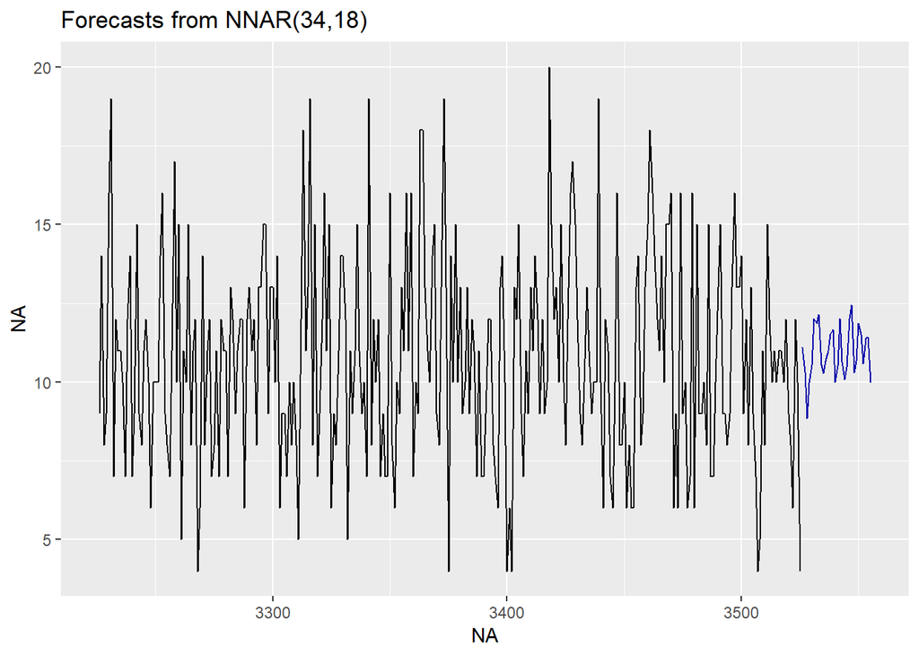

```r
pred_nn<-forecast(fit_nn,h=30)
autoplot(pred_nn,holdout=collision_ts, include = 300)
```

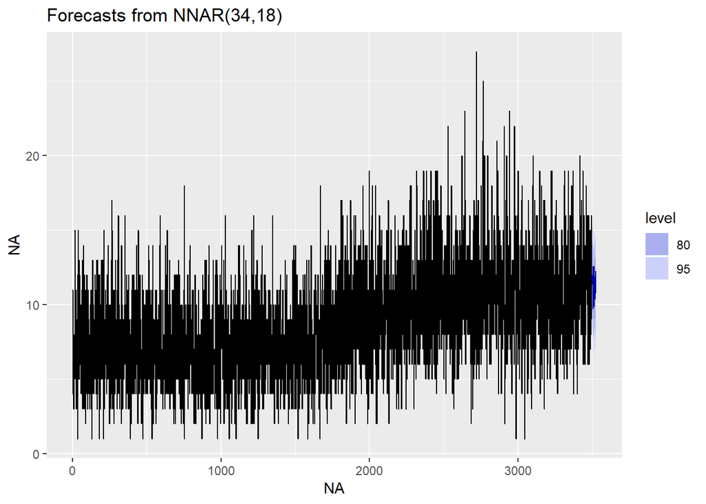

```r
collision_train<-window(collision_ts,end=3500)
collision_test<-window(collision_ts,start=3501)

fit_nn<-nnetar(collision_train)
pred_nn<-forecast(fit_nn,h=25,PI = TRUE)
autoplot(pred_nn,holdout=collision_ts)
```

```r
accuracy(pred_nn,collision_test)
```

```
##                         ME     RMSE      MAE       MPE     MAPE      MASE
## Training set  0.0002689753 1.771167 1.385027 -10.39328 21.64094 0.4038843
## Test set     -1.7383021685 3.340398 2.480941 -32.76342 38.44833 0.7234613
##                     ACF1 Theil's U
## Training set -0.01292888        NA
## Test set      0.10272819  1.043486
```

The accuracy results of the three different approaches show that the ARIMA model with the minimum BIC provides lower errors compared to the other models.

```r
area_name_table<-as.data.table(collision$area_name%>%table())
area_name_table$.
```

```
##  [1] "77th Street" "Central"     "Devonshire"  "Foothill"    "Harbor"
##  [6] "Hollenbeck"  "Hollywood"   "Mission"     "N Hollywood" "Newton"
## [11] "Northeast"   "Olympic"     "Pacific"     "Rampart"     "Southeast"
## [16] "Southwest"   "Topanga"     "Van Nuys"    "West LA"     "West Valley"
## [21] "Wilshire"
```

Here we do the same thing for other areas of LA to find ARIMA models with minimum BICc: (This chunk creates a table (al_areas) which contain all 21 areas in LA with their best p and q which result in the minimum BIC for their corresponding model)

```r
all_areas <- as.data.table(matrix(0,21,6))
for(k in 1:21){


collision_daily <- collision[collision$area_name==area_name_table$.[k],] %>%
  group_by(date) %>%
  summarize(count = n()) %>%
  arrange(date)

collision_daily
collision_ts<-as.ts(collision_daily$count)

ndiffs(collision_ts)

outp <- matrix(0,4*5,5)
count <- 1
for(i in 0:3){
  for(j in 0:4){
    #model <- Arima(collision_ts,c(i,1,j),method = "ML")
    model <- Arima(collision_ts,c(i,1,j))

    outp[count,] <- c(i,1,j,AIC(model),BIC(model))
    count <- count + 1
  }
}
outp <- data.table(outp)
names(outp) <- c('p','d','q','aic','bic')
outp[aic==0,]$aic <- 99999
outp[bic==0,]$bic <- 99999
outp[which.min(outp$aic),,]
outp[which.min(outp$bic),,]


all_areas[k,] <- c(k,outp[which.min(outp$bic),,][,1],1,outp[which.min(outp$bic),,][,3], outp[which.min(outp$bic),,][,4],outp[which.min(outp$bic),,][,5])
names(all_areas)<-c('Area Name','p','d','q','aic','min bic')


}
all_areas
```

| Area Name | p | d | q | aic | min bic |
| --- | --- | --- | --- | --- | --- |
| 1 | 3 | 1 | 4 | 18011.38 | 18060.71 |
| 2 | 3 | 1 | 4 | 16622.42 | 16671.73 |
| 3 | 3 | 1 | 4 | 17261.54 | 17310.87 |
| 4 | 0 | 1 | 1 | 15479.92 | 15492.24 |
| 5 | 0 | 1 | 1 | 15886.24 | 15898.56 |
| 6 | 0 | 1 | 1 | 15835.00 | 15847.31 |
| 7 | 3 | 1 | 4 | 17164.70 | 17214.03 |
| 8 | 0 | 1 | 1 | 16717.51 | 16729.84 |
| 9 | 0 | 1 | 1 | 17580.69 | 17593.03 |
| 10 | 0 | 1 | 1 | 17169.81 | 17182.15 |

[output cut: 11 more lines]

```r
all_areas$`Area Name`<-as.character(all_areas$`Area Name`)
for (i in 0:21){
all_areas$`Area Name`[i]<-area_name_table$.[i]
}
all_areas
```

| Area Name | p | d | q | aic | min bic |
| --- | --- | --- | --- | --- | --- |
| 77th Street | 3 | 1 | 4 | 18011.38 | 18060.71 |
| Central | 3 | 1 | 4 | 16622.42 | 16671.73 |
| Devonshire | 3 | 1 | 4 | 17261.54 | 17310.87 |
| Foothill | 0 | 1 | 1 | 15479.92 | 15492.24 |
| Harbor | 0 | 1 | 1 | 15886.24 | 15898.56 |
| Hollenbeck | 0 | 1 | 1 | 15835.00 | 15847.31 |
| Hollywood | 3 | 1 | 4 | 17164.70 | 17214.03 |
| Mission | 0 | 1 | 1 | 16717.51 | 16729.84 |
| N Hollywood | 0 | 1 | 1 | 17580.69 | 17593.03 |
| Newton | 0 | 1 | 1 | 17169.81 | 17182.15 |

[output cut: 11 more lines]

```r
for(k in 1:21){
  collision_daily <- collision[collision$area_name==area_name_table$.[k],] %>%

  group_by(date) %>%
  summarize(count = n()) %>%
  arrange(date)

ndiffs(collision_ts)
collision_ts<-as.ts(collision_daily$count)

#fit <- arima(collision_ts, order = c(all_areas$p[k],1,all_areas$q[k]),method = "ML")
fit <- arima(collision_ts, order = c(all_areas$p[k],1,all_areas$q[k]))

}
```

This chunk predict the future collision numbers (next 100 days) and save them in a table called: “all_pred THis table is being saved as a”.csv" file and will be used by a shinny app for visualization purposes (using the map of LA)

```r
all_pred <- as.data.table(matrix(0,2100,1))
for(k in 1:21){
  collision_daily <- collision[collision$area_name==area_name_table$.[k],] %>%
  group_by(date) %>%
  summarize(count = n()) %>%
  arrange(date)

collision_ts<-as.ts(collision_daily$count)
fit <- arima(collision_ts, order = c(all_areas$p[k],1,all_areas$q[k]))
forecast<-as.data.table(forecast(fit,h=100))
  for (i in 1:100){
    j<-(k-1)*100+i
    all_pred[j]<-forecast[i,1]
  }

}
write.csv(all_pred, "all_pred.csv")
```

In this chunk, location data of the original data set is being used. For that purpose, the longitude and latitude of the locations should be extracted from the “Location” string (that string contains different information about the location but we just need the longitude and latitude numbers.) This is an axample of a location value in one row of the dataset: {‘latitude’: ‘34.1975’, ‘longitude’: ‘-118.5623’, ‘human_address’: ’{“address”: "“,”city“:”“,”state“:”“,”zip“:”“}’} So we need to work on the string and extract the”lon" and “lat” values: (the extracted coordinates will be added to “collision_lat_lon” table and saved as a “.csv” for the shinny app)

```r
collision_location<-rm_between(collision$Location, "'", "'", extract=TRUE)
length(collision_location)
```

```
## [1] 488384
```

```r
collision_lat_lon<-as.data.table(matrix(0,length(collision_location),2))
for (i in 1:length(collision_location)){
  collision_lat_lon[i,1]<-as.double(collision_location[[i]][2])
  collision_lat_lon[i,2]<-as.double(collision_location[[i]][4])
}
write.csv(collision_lat_lon, "collision_lat_lon.csv")
```

and the numbers of longitudes and latidudes are added to the new columns in the man dataset

```r
collision_lat_lon<-as.matrix(collision_lat_lon)
collision$latitude<-as.numeric(collision_lat_lon[,1])
collision$longitude<-as.numeric(collision_lat_lon[,2])

collision_1<-collision
write.csv(collision_1, "collision_1.csv")
```

In this chunk, we take average of lonitude and latiude numbers for each area. It gives the spots in the areas which are actually centers of the acident locations in those areas.These sports are useful for visualization purposes. Using these spots on the map, we can have some ideas about the places which will have higher number of accidents.

```r
for(k in 1:21){
  col<-collision[collision$area_name==all_areas$`Area Name`[k],]
  all_areas$mean_lat[k]<-mean(col$latitude)
  all_areas$mean_lon[k]<-mean(col$longitude)
  }
```

Here, we can make a table which contains total number of predicted accidents for a specific time period in the future (for example in the “f” following days totally or in the “n”th day from now) In this chunk two random values are selected. But in the shiny app, the time can be used by the user. So the data about the entered time selected by the user will be shown on the map.

```r
f<-7
n<-4
j<-0
for(k in 1:21){
  all_areas$sum[k]<-0
  for (i in 1:f){
    j<-(k-1)*100+i
    all_areas$sum[k]<-all_pred[j]+all_areas$sum[k]
  }
}
for(k in 1:21){
    j<-(k-1)*100+n
    all_areas$n_day[k]<-all_pred[j]
}
all_areas$sum<-as.numeric(all_areas$sum)
all_areas$n_day<-as.numeric(all_areas$n_day)
write.csv(all_areas, "all_areas.csv")
```

In this chunk, predicted number of accidents in different areas are shown on the map.The time period was selected in the previous chunks. However it can be customzed by the user in the shiny app. THe color of the circles shows the number of accidents in the areas. (red: more accidents, green: less, yellow: something in between). If you put the mouse pointer on the spots you can see the predicted numbers. If you click on the spot, the area name will be shown.

```r
register_google(key = "YOUR_API_KEY")
has_google_key()
```

```
## [1] TRUE
```

```r
pal<-colorNumeric("RdYlGn",domain = as.numeric(all_areas$n_day),reverse = TRUE)
m <- leaflet(all_areas) %>%
addTiles() %>%
addCircleMarkers(lng = all_areas$mean_lon, lat = all_areas$mean_lat,popup = all_areas$`Area Name`,fillOpacity = 0.8,stroke = TRUE ,radius = 15,color = pal(as.numeric(all_areas$n_day)),label =as.character(ceiling(as.numeric(all_areas$sum))))

m
```

[interactive chart not shown]